# Tutorial of group-based SHAP

Jeremy Rohmer

2024-02-02

# Introduction

This tutorial shows an example of how to apply the group-based SHAP approach to decompose the prediction uncertainty. The data are based on the vignette of the R package [CAST](https://hannameyer.github.io/CAST/articles/cast02-AOA-tutorial.html).

### Getting started

```r
library(terra)## spatial analysis
library(viridis)##color
library(sf)##for spatial analysis
library(corrplot)##for matrix of pairwise coefficients
library(cluster)## for PAM clustering
library(sensitivity)##for HSIC-based analysis
library(ranger)##for qRF training
library(shapr)## for SHAP
library(gridExtra)
library(ggplot2)

rm(list=ls())

set.seed(12345)
```

## Step 0. Get data

### Generate Predictors

As predictor variables, a set of bioclimatic variables are used (https://www.worldclim.org).

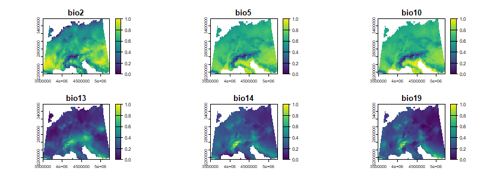

```r
predictors <- rast("bioclim.tif")

## normalisation between 0 and 1
for (i in 1:length(names(predictors))){
    v = values(predictors[[i]])
    values(predictors[[i]]) = (v - min(v,na.rm=T)) / (max(v,na.rm=T) - min(v,na.rm=T))
}

plot(predictors,col=viridis(100))
```

### Generate Response

To be able to test the reliability of the method, we are using a simulated prediction task. We therefore simulate a virtual response variable from the bioclimatic variables.

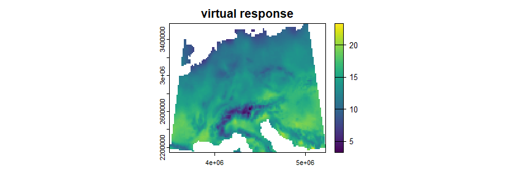

```r
response <- 10*predictors$bio2+5*predictors$bio5+5*predictors$bio10+5*predictors$bio13+
        0.0001*predictors$bio14+0.0001*predictors$bio19
names(response) = "response"
plot(response,col=viridis(100),main="virtual response")
```

### Simulate sampling locations

```r
mask <- predictors[[1]]
values(mask)[!is.na(values(mask))] <- 1
mask <- st_as_sf(as.polygons(mask))
mask <- st_make_valid(mask)
```

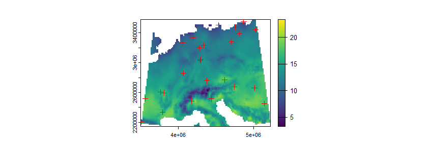

```r
samplepoints <- st_as_sf(st_sample(mask,25,"random"))
xy0 = st_coordinates(samplepoints)##coordinates
plot(response,col=viridis(100))
plot(samplepoints,col="red",add=T,pch=3)
```

### Prepare data

Then, predictors and response are extracted for the sampling locations.

```r
trainDat <- terra::extract(predictors,samplepoints,na.rm=FALSE)
trainDat$response <- unlist(terra::extract(response,samplepoints,na.rm=FALSE, ID=FALSE))
trainDat <- na.omit(trainDat)
trainDat <- trainDat[,-1]
x_train = trainDat[,-c(ncol(trainDat))]
```

We also extract the test data at a series of grid points over the study area. Here, we use *N*=100, but a larger number can be used.

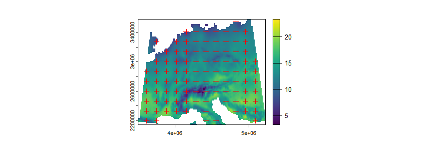

```r
N = 100
gridpoints <- st_as_sf(st_sample(mask,N,type="regular"))
xy = st_coordinates(gridpoints)##coordinates
plot(response,col=viridis(100))
plot(gridpoints,col="red",add=T,pch=3)
```

```r
testDat <- terra::extract(predictors,gridpoints,na.rm=FALSE)
testDat$response <- unlist(terra::extract(response,gridpoints,na.rm=FALSE, ID=FALSE))
testDat <- na.omit(testDat)
testDat <- testDat[,-1]
x_test = testDat[,-ncol(testDat)]
```

## Step 1. Screening analysis

HSIC-based screening analysis is applied. The following figure gives the p-value. Recall that a p-value superior to 5% suggests that the corresponding covariate is non-influential. By construction, the two last variables, *bio14* and *bio19*, have negligible influence, which is here confirmed.

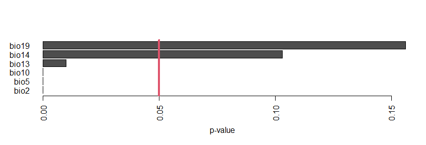

```r
sensi <- sensiHSIC(model=NULL, X = data.frame(x_train),
                    kernelX=c(rep("rbf",ncol(x_train))),
                    kernelY="rbf"
                    )
ss = tell(sensi, y=data.frame(trainDat$response))
test.perm <- testHSIC(ss, test.method="Seq_Permutation",seq.options = list(criterion = "screening",alpha = 0.05,graph = FALSE))
barplot(t(unlist(test.perm$pval)),names.arg=names(x_train),las=2,horiz=T,angle=90,xlab="p-value")
abline(v=0.05,col=2,lwd=4)
```

we filter out the non-influential covariates (p-value > 5%).

```r
filtre = which(test.perm$pval<0.05)
x_train = x_train[,filtre]
x_test = x_test[,filtre]
```

## Step 2. Train the qRF model

Quantile random Forest is applied here as machine learning algorithm (others can be used as well, as long as prediction uncertainty is estimated). The prediction uncertainty is measured here by the inter-quartile width.

```r
df.tr = data.frame(
  X = x_train,
  Y = trainDat$response
)
names(df.tr) = c(names(x_train),"Y")
df.tr = na.omit(df.tr)

model <- ranger(
  formula = Y~.,
  data = df.tr,
  num.trees = 1000,
  mtry=3,
  min.node.size = 5,
  respect.unordered.factors = FALSE,
  quantreg = TRUE
)
print(model)
```

```
## Ranger result
##
## Call:
##  ranger(formula = Y ~ ., data = df.tr, num.trees = 1000, mtry = 3,      min.node.size = 5, respect.unordered.factors = FALSE, quantreg = TRUE)
##
## Type:                             Regression
## Number of trees:                  1000
## Sample size:                      25
## Number of independent variables:  4
## Mtry:                             3
## Target node size:                 5
## Variable importance mode:         none
## Splitrule:                        variance
## OOB prediction error (MSE):       1.134303
## R squared (OOB):                  0.8785344
```

```r
modelM <- ranger(
  formula = Y~.,
  data = df.tr,
  num.trees = 1000,
  mtry=3,
  min.node.size = 5,
  respect.unordered.factors = FALSE
)
print(modelM)
```

```
## Ranger result
##
## Call:
##  ranger(formula = Y ~ ., data = df.tr, num.trees = 1000, mtry = 3,      min.node.size = 5, respect.unordered.factors = FALSE)
##
## Type:                             Regression
## Number of trees:                  1000
## Sample size:                      25
## Number of independent variables:  4
## Mtry:                             3
## Target node size:                 5
## Variable importance mode:         none
## Splitrule:                        variance
## OOB prediction error (MSE):       1.168351
## R squared (OOB):                  0.8748884
```

```r
## mean prediction
PRED = predict(modelM,x_test)
##quartile prediction
PREDQ = predict(model,x_test,type = "quantiles", quantiles = c(.25,.75))
```

We plot the true values, the predictions and the uncertainty.

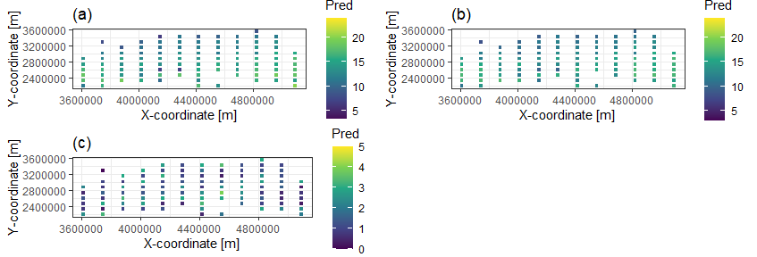

```r
df.plt50 = data.frame(X = xy[,1],Y = xy[,2],Pred = PREDQ$predictions[,2]- PREDQ$predictions[,1])
plt.unc =  ggplot(df.plt50,aes(X,Y,color=Pred)) +
    geom_point(size=1,shape=15)+xlab("X-coordinate [m]")+ylab("Y-coordinate [m]")+
    scale_colour_viridis_c(limits=c(0,5))+theme_bw()+
    guides(size = guide_legend(order=2))+ggtitle("(c)")

df.plt = data.frame(X = xy[,1],Y = xy[,2],Pred = PRED$predictions)
plt.mean =  ggplot(df.plt,aes(X,Y,color=Pred)) +
    geom_point(size=1,shape=15)+xlab("X-coordinate [m]")+ylab("Y-coordinate [m]")+
    scale_colour_viridis_c(limits=c(3,24))+theme_bw()+
    guides(size = guide_legend(order=2))+ggtitle("(b)")

df.plt = data.frame(X = xy[,1],Y = xy[,2],Pred = testDat$response)
plt.true =  ggplot(df.plt,aes(X,Y,color=Pred)) +
    geom_point(size=1,shape=15)+xlab("X-coordinate [m]")+ylab("Y-coordinate [m]")+
    scale_colour_viridis_c(limits=c(3,24))+theme_bw()+
    guides(size = guide_legend(order=2))+ggtitle("(a)")

grid.arrange(grobs=list(plt.true,plt.mean,plt.unc), ncol = 2,common.legend = TRUE, legend="top")
```

## Step 3. Group definition

We first compute the matrix of pairwise HSIC-based dependence measures using the following function *pairwiseHSIC()*.

```r
# HSIC
pairwiseHSIC = function(x){
C = matrix(0,ncol(x),ncol(x))
p.mat = matrix(0,ncol(x),ncol(x))
for (i in 1:ncol(x)){
    print(i)
    for (j in (1:ncol(x))[-i]){

        x0 = x[,i]#matrix(x[,i],ncol=1)
        y0 = x[,j]#matrix(x[,j],ncol=1)

        if (is.numeric(x0) & is.numeric(y0)){
        sensi <- sensiHSIC(model=NULL, X = data.frame(x0),
                    kernelX="rbf",
                    paramX=NA,
                    kernelY="rbf", paramY=NA,
                    nboot = 0, conf = 0.95
                    )
        }else if (is.factor(x0) & is.numeric(y0)){
        sensi <- sensiHSIC(model=NULL, X = data.frame(x0),
                    kernelX="categ",
                    paramX=NA,
                    kernelY="rbf", paramY=NA,
                    nboot = 0, conf = 0.95
                    )
        }else if (is.factor(x0) & is.factor(y0)){
        sensi <- sensiHSIC(model=NULL, X = data.frame(x0),
                    kernelX="categ",
                    paramX=NA,
                    kernelY="categ", paramY=NA,
                    nboot = 0, conf = 0.95
                    )
        }else if (is.numeric(x0) & is.factor(y0)){
        sensi <- sensiHSIC(model=NULL, X = data.frame(x0),
                    kernelX="rbf",
                    paramX=NA,
                    kernelY="categ", paramY=NA,
                    nboot = 0, conf = 0.95
                    )
        }
        ss = tell(sensi, y=data.frame(y0))
        C[i,j] = as.numeric(unlist(ss$S["original"]))
        test.perm <- testHSIC(ss, test.method="Gamma")
        p.mat[i,j] <- as.numeric(unlist(test.perm$pval))
    }
}

C = data.frame(C)
p.mat = data.frame(p.mat)
rownames(C) = colnames(C) = names(x)
rownames(p.mat) = colnames(p.mat) = names(x)
return(list(C=C,pval=p.mat))
}
```

```r
C0 = pairwiseHSIC(x_train)
```

```
## [1] 1
## [1] 2
## [1] 3
## [1] 4
```

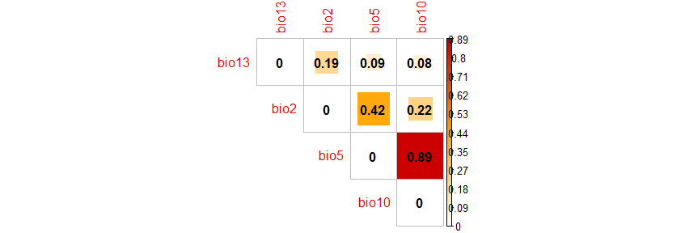

```r
C = C0$C
P = C0$pval
C = data.frame(C)
rownames(C) = colnames(C) = names(x_train)
corrplot(as.matrix(C), method = 'square', order = 'hclust', type = 'upper',addCoef.col ='black',
        col=colorRampPalette(c("white","orange","red3"))(100), is.corr = FALSE)
```

On this basis, we then perform the grouping using the PAM algorithm with 3 groups.

```r
DD = as.dist(1-C)
kk = 3
CLUS = pam(DD,kk,diss = TRUE,medoids = NULL)

group_ts <- list()
for (i in 1:kk){
    group_ts[[i]] = names(x_train)[which(CLUS$clustering==i)]
}

names(group_ts) = c("bio2","bio5-10","bio13")
print(group_ts)
```

```
## $bio2
## [1] "bio2"
##
## $`bio5-10`
## [1] "bio5"  "bio10"
##
## $bio13
## [1] "bio13"
```

## Step 4. Application of the group-based SHAP

We apply the group-based SHAP to decompose the inter-quartile width at the grid points.

```r
MY_predict_model <- function(x, newdata) {
    qq = predict(x, data=newdata, type="quantiles",quantiles=c(0.25,0.75))
    return(qq$predictions[,2]-qq$predictions[,1])
}

system.time(explanationQ <- shapr::explain(
  model = model,
  x_explain = x_test,
  x_train = x_train,
  approach = "ctree",
  prediction_zero = 0,
  predict_model = MY_predict_model,
  get_model_specs = NULL,
  group = group_ts,
  n_batches = 1
)
)
```

```
## utilisateur     système      écoulé
##        3.11        0.23        3.38
```

We then apply the group-based SHAP to decompose the mean prediction at the grid points.

```r
MY_predict_model <- function(x, newdata) {
  qq = predict(x, data=newdata)
  return(qq$predictions)
}

system.time(explanationM <- shapr::explain(
  model = modelM,
  x_explain = x_test,
  x_train = x_train,
  approach = "ctree",
  prediction_zero = 0,
  predict_model = MY_predict_model,
  get_model_specs = NULL,
  group = group_ts,
  n_batches = 1
)
)
```

```
## utilisateur     système      écoulé
##        1.22        0.16        1.14
```

Example of decomposition for the first case.

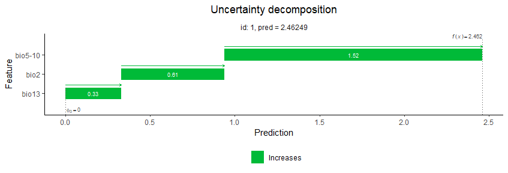

```r
case = 1
plot(explanationQ,index_x_explain=case, plot_type = "waterfall")+ggtitle("Uncertainty decomposition")
```

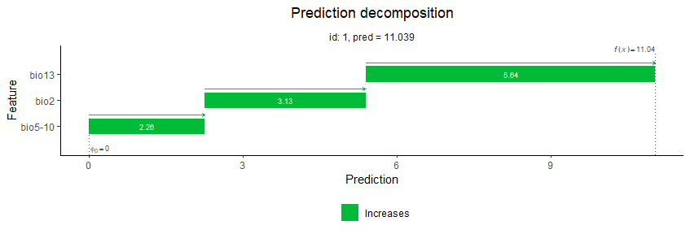

```r
plot(explanationM,index_x_explain=case, plot_type = "waterfall")+ggtitle("Prediction decomposition")
```

## Further reading

- Rohmer et al. (2023) Insights into the prediction uncertainty of machine-learning-based digital soil mapping through a local attribution approach. egusphere-2024-323